# Project 1 phase2

# Performance We will check the performance of used classifiers with confusion matrix, Area Under Curve (AUC) and Macro Averaged Metrics.

## Confusion Matrix Confusion matrix is a table describing performance of classifiers. Besides, confusionMatrix() function also provides additional statistics.

```r
#Random Forest
rfConfusionMatrix <- confusionMatrix(predForest, dataTest$HeartDisease)
rfConfusionMatrix
```

```
## Confusion Matrix and Statistics
##
##           Reference
## Prediction  0  1
##          0 30 10
##          1 13 22
##
##                Accuracy : 0.6933
##                  95% CI : (0.5762, 0.7947)
##     No Information Rate : 0.5733
##     P-Value [Acc > NIR] : 0.02227
##
##                   Kappa : 0.3806
##  Mcnemar's Test P-Value : 0.67666
##
##             Sensitivity : 0.6977
##             Specificity : 0.6875
##          Pos Pred Value : 0.7500
##          Neg Pred Value : 0.6286
##              Prevalence : 0.5733
##          Detection Rate : 0.4000
##    Detection Prevalence : 0.5333
##       Balanced Accuracy : 0.6926
##
##        'Positive' Class : 0
##
```

```r
#Tree
treeConfusionMatrix <- confusionMatrix(predTree, dataTest$HeartDisease)
treeConfusionMatrix
```

```
## Confusion Matrix and Statistics
##
##           Reference
## Prediction  0  1
##          0 31  7
##          1 12 25
##
##                Accuracy : 0.7467
##                  95% CI : (0.633, 0.8401)
##     No Information Rate : 0.5733
##     P-Value [Acc > NIR] : 0.001387
##
##                   Kappa : 0.4923
##  Mcnemar's Test P-Value : 0.358795
##
##             Sensitivity : 0.7209
##             Specificity : 0.7812
##          Pos Pred Value : 0.8158
##          Neg Pred Value : 0.6757
##              Prevalence : 0.5733
##          Detection Rate : 0.4133
##    Detection Prevalence : 0.5067
##       Balanced Accuracy : 0.7511
##
##        'Positive' Class : 0
##
```

```r
#Nearest Neighbours
knnConfusionMatrix <- confusionMatrix(predKnn, dataTest$HeartDisease)
knnConfusionMatrix
```

```
## Confusion Matrix and Statistics
##
##           Reference
## Prediction  0  1
##          0 31  8
##          1 12 24
##
##                Accuracy : 0.7333
##                  95% CI : (0.6186, 0.8289)
##     No Information Rate : 0.5733
##     P-Value [Acc > NIR] : 0.003042
##
##                   Kappa : 0.4635
##  Mcnemar's Test P-Value : 0.502335
##
##             Sensitivity : 0.7209
##             Specificity : 0.7500
##          Pos Pred Value : 0.7949
##          Neg Pred Value : 0.6667
##              Prevalence : 0.5733
##          Detection Rate : 0.4133
##    Detection Prevalence : 0.5200
##       Balanced Accuracy : 0.7355
##
##        'Positive' Class : 0
##
```

```r
#SVM
svmConfusionMatrix <- confusionMatrix(predSVM, dataTest$HeartDisease)
svmConfusionMatrix
```

```
## Confusion Matrix and Statistics
##
##           Reference
## Prediction  0  1
##          0 31  8
##          1 12 24
##
##                Accuracy : 0.7333
##                  95% CI : (0.6186, 0.8289)
##     No Information Rate : 0.5733
##     P-Value [Acc > NIR] : 0.003042
##
##                   Kappa : 0.4635
##  Mcnemar's Test P-Value : 0.502335
##
##             Sensitivity : 0.7209
##             Specificity : 0.7500
##          Pos Pred Value : 0.7949
##          Neg Pred Value : 0.6667
##              Prevalence : 0.5733
##          Detection Rate : 0.4133
##    Detection Prevalence : 0.5200
##       Balanced Accuracy : 0.7355
##
##        'Positive' Class : 0
##
```

```r
#Multinomial Logistic Regression
mlrConfusionMatrix <- confusionMatrix(predVglm, dataTest$HeartDisease)
mlrConfusionMatrix
```

```
## Confusion Matrix and Statistics
##
##           Reference
## Prediction  0  1
##          0 32  9
##          1 11 23
##
##                Accuracy : 0.7333
##                  95% CI : (0.6186, 0.8289)
##     No Information Rate : 0.5733
##     P-Value [Acc > NIR] : 0.003042
##
##                   Kappa : 0.4593
##  Mcnemar's Test P-Value : 0.823063
##
##             Sensitivity : 0.7442
##             Specificity : 0.7188
##          Pos Pred Value : 0.7805
##          Neg Pred Value : 0.6765
##              Prevalence : 0.5733
##          Detection Rate : 0.4267
##    Detection Prevalence : 0.5467
##       Balanced Accuracy : 0.7315
##
##        'Positive' Class : 0
##
```

```r
#Naive Bayes
bayesConfusionMatrix <- confusionMatrix(predBayes, dataTest$HeartDisease)
bayesConfusionMatrix
```

```
## Confusion Matrix and Statistics
##
##           Reference
## Prediction  0  1
##          0 29  8
##          1 14 24
##
##                Accuracy : 0.7067
##                  95% CI : (0.5902, 0.8062)
##     No Information Rate : 0.5733
##     P-Value [Acc > NIR] : 0.01216
##
##                   Kappa : 0.4145
##  Mcnemar's Test P-Value : 0.28642
##
##             Sensitivity : 0.6744
##             Specificity : 0.7500
##          Pos Pred Value : 0.7838
##          Neg Pred Value : 0.6316
##              Prevalence : 0.5733
##          Detection Rate : 0.3867
##    Detection Prevalence : 0.4933
##       Balanced Accuracy : 0.7122
##
##        'Positive' Class : 0
##
```

## Area Under Curve Receiver Operating Characteristics curve (ROC) visualises the performance of a classifier. AUC is the Area Under the ROC Curve, where the value equal to 1 means a perfect test.

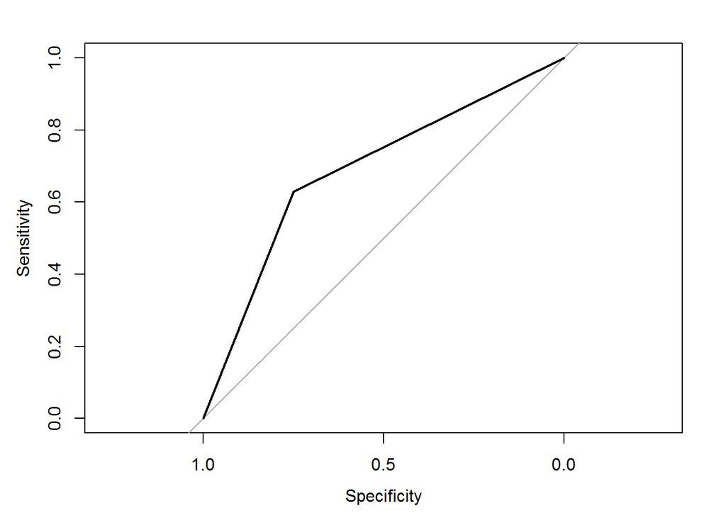

```r
#Random Forest
rfAUC <- auc(predForest, as.numeric(dataTest$HeartDisease))
rfrocobj <- plot.roc(predForest, as.numeric(dataTest$HeartDisease))
```

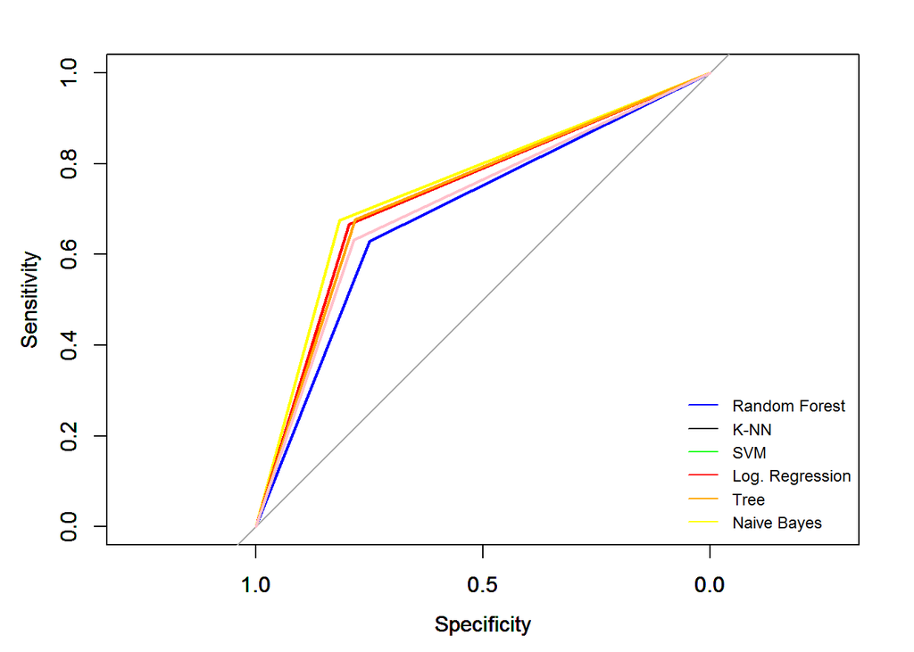

```r
plot(rfrocobj, col="blue")
par(new = TRUE)


#Tree
treeAUC <- auc(predTree, as.numeric(dataTest$HeartDisease))
treerocobj <- plot.roc(predTree, as.numeric(dataTest$HeartDisease))
plot(treerocobj, col="yellow", add=TRUE)
par(new = TRUE)

#Nearest Neighbours
knnAUC <- auc(predForest, as.numeric(dataTest$HeartDisease))
knnrocobj <- plot.roc(predKnn, as.numeric(dataTest$HeartDisease))
plot(knnrocobj, col="green", add=TRUE)
par(new = TRUE)

#SVM
svmAUC <- auc(predSVM, as.numeric(dataTest$HeartDisease))
svmrocobj <- plot.roc(predSVM, as.numeric(dataTest$HeartDisease))
plot(svmrocobj, col="red", add=TRUE)
par(new = TRUE)

#Multinomial Logistic Regression
vglmAUC <- auc(predVglm, as.numeric(dataTest$HeartDisease))
vglmrocobj <- plot.roc(predVglm, as.numeric(dataTest$HeartDisease))
plot(vglmrocobj, col="orange", add=TRUE)
par(new = TRUE)


#Naive Bayes
bayesAUC <- auc(predBayes, as.numeric(dataTest$HeartDisease))
bayesrocobj <- plot.roc(predBayes, as.numeric(dataTest$HeartDisease))
plot(bayesrocobj, col="pink", add=TRUE)

legend('bottomright', c('Random Forest','K-NN', 'SVM', 'Log. Regression', 'Tree', 'Naive Bayes'), lty=1, col=c('blue', 'black', 'green', 'red',' orange', 'yellow', 'pink'), bty='n', cex=.75)
```

##Macro-Averaged Metrics Tables for In Macro-averaged Metrics give an average of the following:

Precision = TP / (TP+FP), fraction of correct predictions for a certain class.

Recall = TP / (TP+FN), instances of a class that were correctly predicted.

Precision shows how consistent are those evaluations - how many values were correctly estimated.

F1 is a harmonic mean of precision and recall. That is why has a very similar values like Precision and Recall and shows that those values are not various from each other.

```r
#RandomForest

forestPrec<-(diag(forestTab))/(colSums(forestTab))
forestRecall<-(diag(forestTab))/(rowSums(forestTab))
forestF1<-2*forestPrec*forestRecall/(forestPrec+forestRecall)

data.frame(forestPrec, forestRecall, forestF1)
```

```
##   forestPrec forestRecall  forestF1
## 0  0.7500000    0.6976744 0.7228916
## 1  0.6285714    0.6875000 0.6567164
```

```r
mForestPrec = mean(forestPrec)
mForestRecall = mean(forestRecall)
mForestF1 = mean(forestF1)
mamForest<-data.frame(mForestPrec, mForestRecall, mForestF1)
mamForest
```

```
##   mForestPrec mForestRecall mForestF1
## 1   0.6892857     0.6925872  0.689804
```

```r
#Tree

treePrec<-(diag(treeTab))/(colSums(treeTab))
treeRecall<-(diag(treeTab))/(rowSums(treeTab))
treeF1<-2*treePrec*treeRecall/(treePrec+treeRecall)

data.frame(treePrec, treeRecall, treeF1)
```

```
##    treePrec treeRecall    treeF1
## 0 0.8157895  0.7209302 0.7654321
## 1 0.6756757  0.7812500 0.7246377
```

```r
mTreePrec = mean(treePrec)
mTreeRecall = mean(treeRecall)
mTreeF1 = mean(treeF1)
mamTree<-data.frame(mTreePrec, mTreeRecall, mTreeF1)
mamTree
```

```
##   mTreePrec mTreeRecall   mTreeF1
## 1 0.7457326   0.7510901 0.7450349
```

```r
#Nearest Neighbours

knnPrec<-(diag(tab_optimal))/(colSums(tab_optimal))
knnRecall<-(diag(tab_optimal))/(rowSums(tab_optimal))
knnF1<-2*knnPrec*knnRecall/(knnPrec+knnRecall)

data.frame(knnPrec, knnRecall, knnF1)
```

```
##     knnPrec knnRecall     knnF1
## 0 0.7948718 0.7209302 0.7560976
## 1 0.6666667 0.7500000 0.7058824
```

```r
mKnnPrec = mean(knnPrec)
mKnnRecall = mean(knnRecall)
mKnnF1 = mean(knnF1)
mamKnn<-data.frame(mKnnPrec, mKnnRecall, mKnnF1)
mamKnn
```

```
##    mKnnPrec mKnnRecall  mKnnF1
## 1 0.7307692  0.7354651 0.73099
```

```r
#SVM

svmPrec<-(diag(svmTab))/(colSums(svmTab))
svmRecall<-(diag(svmTab))/(rowSums(svmTab))
svmF1<-2*svmPrec*svmRecall/(svmPrec+svmRecall)

data.frame(svmPrec, svmRecall, svmF1)
```

```
##     svmPrec svmRecall     svmF1
## 0 0.7948718 0.7209302 0.7560976
## 1 0.6666667 0.7500000 0.7058824
```

```r
mSvmPrec = mean(svmPrec)
mSvmRecall = mean(svmRecall)
mSvmF1 = mean(svmF1)
mamSvm<-data.frame(mSvmPrec, mSvmRecall, mSvmF1)
mamSvm
```

```
##    mSvmPrec mSvmRecall  mSvmF1
## 1 0.7307692  0.7354651 0.73099
```

```r
#Multinomial Logistic Regression

vglmPrec<-(diag(vglmTab))/(colSums(vglmTab))
vglmRecall<-(diag(vglmTab))/(rowSums(vglmTab))
vglmF1<-2*vglmPrec*vglmRecall/(vglmPrec+vglmRecall)

data.frame(vglmPrec, vglmRecall, vglmF1)
```

```
##    vglmPrec vglmRecall    vglmF1
## 0 0.7804878   0.744186 0.7619048
## 1 0.6764706   0.718750 0.6969697
```

```r
mVglmPrec = mean(vglmPrec)
mVglmRecall = mean(vglmRecall)
mVglmF1 = mean(vglmF1)
mamVglm<-data.frame(mVglmPrec, mVglmRecall, mVglmF1)
mamVglm
```

```
##   mVglmPrec mVglmRecall   mVglmF1
## 1 0.7284792    0.731468 0.7294372
```

```r
#Bayes

bayesPrec<-(diag(bayesTab))/(colSums(bayesTab))
bayesRecall<-(diag(bayesTab))/(rowSums(bayesTab))
bayesF1<-2*bayesPrec*bayesRecall/(bayesPrec+bayesRecall)

data.frame(bayesPrec, bayesRecall, bayesF1)
```

```
##   bayesPrec bayesRecall   bayesF1
## 0 0.7837838   0.6744186 0.7250000
## 1 0.6315789   0.7500000 0.6857143
```

```r
mBayesPrec = mean(bayesPrec)
mBayesRecall = mean(bayesRecall)
mBayesF1 = mean(bayesF1)
mamBayes<-data.frame(mBayesPrec, mBayesRecall, mBayesF1)
mamBayes
```

```
##   mBayesPrec mBayesRecall  mBayesF1
## 1  0.7076814    0.7122093 0.7053571
```

```r
#Conclusions

sum_table <- matrix(c(rfAcc, rfAUC, mForestPrec, mForestRecall, mForestF1,   treeAcc, treeAUC, mTreePrec, mTreeRecall, mTreeF1, knnAcc, knnAUC, mKnnPrec, mKnnRecall, mKnnF1, svmAcc, svmAUC, mSvmPrec, mSvmRecall, mSvmF1, vglmAcc, vglmAUC,mVglmPrec, mVglmRecall, mVglmF1,  bayesAcc, bayesAUC, mBayesPrec, mBayesRecall, mBayesF1), ncol=5, nrow = 6 , byrow = TRUE)
colnames(sum_table) <- c("Accuracy", "AUC","Precision","Recall","F1")
rownames(sum_table) <- c("RF", "TREE", "KNN", "SVM", "MLR", "BAYES")
sum_table
```

```
##        Accuracy       AUC Precision    Recall        F1
## RF    0.6933333 0.6892857 0.6892857 0.6925872 0.6898040
## TREE  0.7466667 0.7457326 0.7457326 0.7510901 0.7450349
## KNN   0.7333333 0.6892857 0.7307692 0.7354651 0.7309900
## SVM   0.7333333 0.7307692 0.7307692 0.7354651 0.7309900
## MLR   0.7333333 0.7284792 0.7284792 0.7314680 0.7294372
## BAYES 0.7066667 0.7076814 0.7076814 0.7122093 0.7053571
```

```r
library(reshape2)
melted_tab <- melt(sum_table)
head(melted_tab)
```

```
##    Var1     Var2     value
## 1    RF Accuracy 0.6933333
## 2  TREE Accuracy 0.7466667
## 3   KNN Accuracy 0.7333333
## 4   SVM Accuracy 0.7333333
## 5   MLR Accuracy 0.7333333
## 6 BAYES Accuracy 0.7066667
```

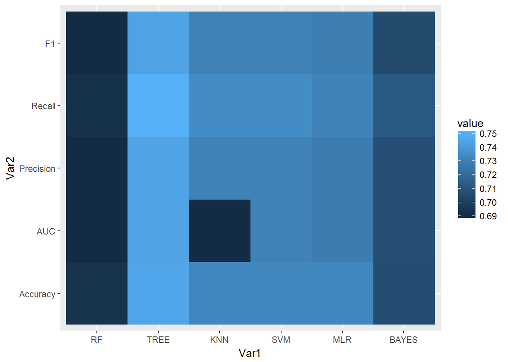

```r
library(ggplot2)
ggplot(data = melted_tab, aes(x=Var1, y=Var2, fill=value)) + geom_tile()
```

```r
library(fields)
```

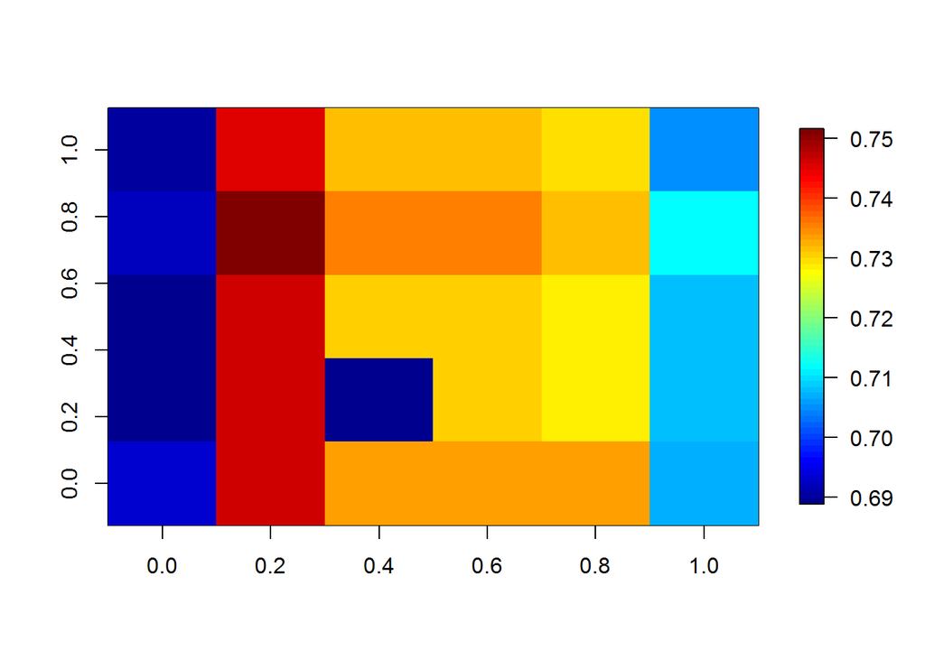

```r
image.plot(matrix((data=sum_table), ncol=5, nrow=6))
```

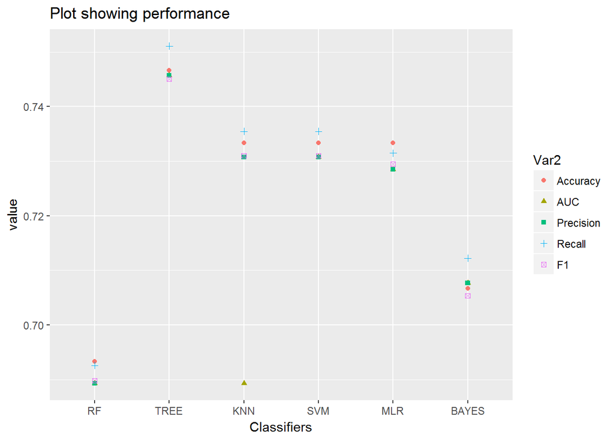

```r
ggplot(melted_tab, aes(x=Var1, y=value, col=Var2,shape=Var2)) + geom_point(size=1.5)+labs(title = "Plot showing performance", x = "Classifiers")
```

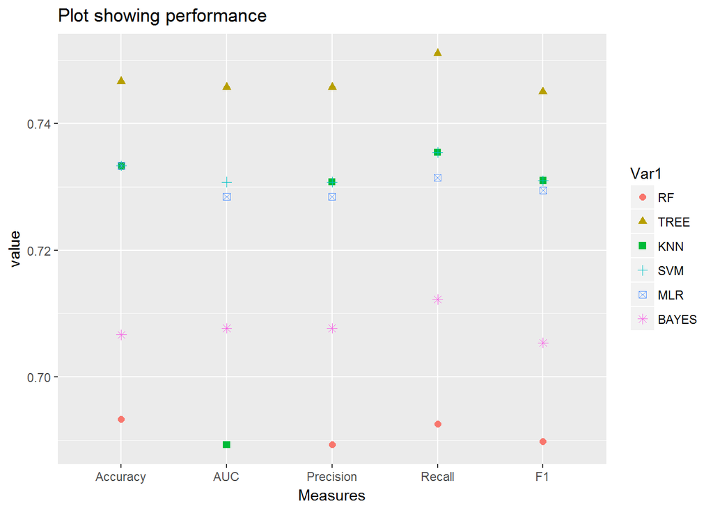

```r
ggplot(melted_tab, aes(x=Var2, y=value, col=Var1,shape=Var1))+ geom_point(size=2.0) +labs(title = "Plot showing performance", x = "Measures")
```

Our task was to find the best classification model for given data set and compare their performance with various methods hence we implemented 6 distinct classifiers. In the summary table above given are: Accuracy, AUC, Precision, Recall and F1.